# Introduction to R

[Saeed Saffari](https://www.saeedsaffari.com) Saeed.Saffari@dal.ca

Winter 2025

# 1 Introduction

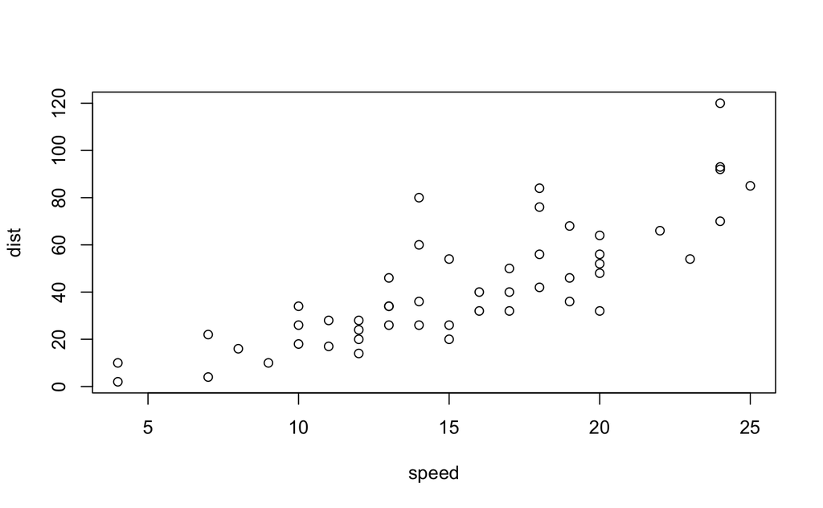

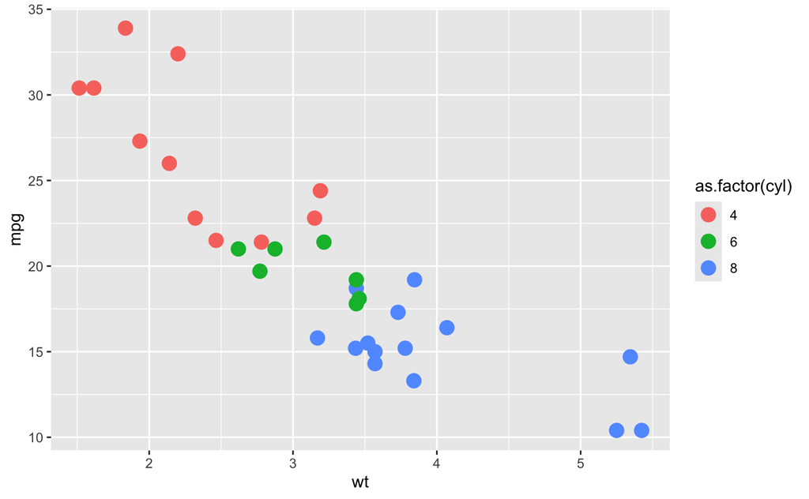

You can download and install packages with `install.packages("The name of package")`.

## 1.1 Markdown:

$$\alpha = \beta = \frac{-\alpha \cdot
\gamma^2}{\sqrt{\sigma^3}}$$

# 2 Basic of learning

In this part we talk about basic elements of R programming.

## 2.1 How to Print

```r
print('Hello world')
```

```
[1] "Hello world"
```

```r
print("This is R programming Workshop!")
```

```
[1] "This is R programming Workshop!"
```

## 2.2 Data Types (Classes)

In R, data types (or classes) define the kind of data stored in variables. Here are the most common data types in R:

| **Class** | **Description** | **Example** | **Code Example** |
| --- | --- | --- | --- |
| `numeric` | Represents decimal or whole numbers | 3.14, 42, -7.8 | `x <- 3.14; class(x)` |
| `character` | Represents text strings | “Hello”, “R Programming” | `z <- "Hello"; class(z)` |
| `logical` | Represents Boolean values (TRUE or FALSE) | TRUE, FALSE | `is_valid <- TRUE; class(is_valid)` |
| `complex` | Represents complex numbers | 2+3i, 1-4i | `c <- 2 + 3i; class(c)` |
| `list` | Represents a collection of different types | A list of numbers, text | `lst <- list(1, "Hello", TRUE); class(lst)` |

```r
print(class(TRUE))
```

```
[1] "logical"
```

## 2.3 Arithmetic Operators

| Symbol | Task Performed |
| --- | --- |
| + | Addition |
| - | Subtraction |
| / | division |
| * | multiplication |
| ** | to the power of |
| ^ | to the power of |
| %% | modulus |
| %/% | floor division |

```r
log10(2)
```

```
[1] 0.30103
```

```r
5 + (4 - 3 * 2)**3 + 1
```

```
[1] -2
```

**We can save values in variables:**

```r
class(z)
```

```
[1] "numeric"
```

In R programming, code runs line by line, with only the last assignment determining the final value of a variable.

```r
a = 5 + (4 - 3 * 2)**3 + 1
a = 10
a = a * 2
a = a - 5
a
```

```
[1] 15
```

### 2.3.1 Practice:

Convert a given temperature X degrees Celsius to Fahrenheit.
$$F= C \cdot \frac{9}{5} + 32$$

```r
temp = 20
fahrenheit <- (temp * 9 / 5) + 32
print(fahrenheit)
```

```
[1] 68
```

## 2.4 Relational Operators

| Symbol | Task Performed |
| --- | --- |
| <- | Assignment |
| = | Assignment |
| assign() | Assignment |
| == | True, if it is equal |
| != | True, if not equal to |
| < | less than |
| > | greater than |
| <= | less than or equal to |
| >= | greater than or equal to |

```r
x > 1 | y > 10
```

```
[1] TRUE
```

**you can use below command to get special values:**

```r
x
```

```
 [1] "Jan" "Feb" "Mar" "Apr" "May" "Jun" "Jul" "Aug" "Sep"
[10] "Oct" "Nov" "Dec"
```

**you can write comment with # :**

```r
# This line is comment!
```

**you can create sequence numbers with below command:**

This work like *arange* in numpy pakage in Python

```r
x
```

```
[1] 1 3 5 7 9
```

This work like *linspace* in numpy pakage in Python

```r
x
```

```
[1]  1.00  3.25  5.50  7.75 10.00
```

Replicate function:

```r
x <- 1:3
x
```

```
[1] 1 2 3
```

```r
y <- rep(x, time = 5)
y
```

```
 [1] 1 2 3 1 2 3 1 2 3 1 2 3 1 2 3
```

```r
y <- rep(x, each = 5)
y
```

```
 [1] 1 1 1 1 1 2 2 2 2 2 3 3 3 3 3
```

## 2.5 Practice:

Simulate GDP growth from the year 2000 to 2025 with an annual growth rate of 3% starting from 1000 units.

$$GDP_{t} = 1000 \cdot
(1+r)^{n}$$

```r
years = 2000:2025
growth_rate <- 0.03 # rate
GDP = 1000 * (1+growth_rate)**(years - 2000)
GDP
```

```
 [1] 1000.000 1030.000 1060.900 1092.727 1125.509 1159.274
 [7] 1194.052 1229.874 1266.770 1304.773 1343.916 1384.234
[13] 1425.761 1468.534 1512.590 1557.967 1604.706 1652.848
[19] 1702.433 1753.506 1806.111 1860.295 1916.103 1973.587
[25] 2032.794 2093.778
```

## 2.6 Loops

### 2.6.1 if , elif

```r
"R" + 2
```

```
Error in "R" + 2 : non-numeric argument to binary operator
```

```r
age <- 15
if (age >= 18){
  print('You are old enough to vote!')
} else {
  print('You can NOT vote yet!')
  print(paste('You can will vote after ', 18 - age, ' years.'))
}
```

```
[1] "You can NOT vote yet!"
[1] "You can will vote after  3  years."
```

```r
age <- 16
if (age <= 4){
  price = 0
} else if (age < 16){
  price = 50
} else if (age >= 16){
  price = 100
}

print(paste("Your cost is $", price))
```

```
[1] "Your cost is $ 100"
```

### 2.6.2 for loops

```r
for (i in 1:5){
  print(i)
}
```

```
[1] 1
[1] 2
[1] 3
[1] 4
[1] 5
```

```r
for (i in 1:5){
  print(i*i)
}
```

```
[1] 1
[1] 4
[1] 9
[1] 16
[1] 25
```

```r
z = 0
for (i in 1:10){
  z = z + i
  print(z)
}
```

```
[1] 1
[1] 3
[1] 6
[1] 10
[1] 15
[1] 21
[1] 28
[1] 36
[1] 45
[1] 55
```

### 2.6.3 while loops

```r
i <- 1
while (i < 10){
  print(i)
  i <- i + 1
}
```

```
[1] 1
[1] 2
[1] 3
[1] 4
[1] 5
[1] 6
[1] 7
[1] 8
[1] 9
```

### 2.6.4 Practice:

Write a conditional statement to check whether the variable is positive, negative, or zero and print the appropriate message.

```r
"It's R"
```

```
[1] "It's R"
```

```r
x <- -5
if (x > 0) {
  print('Positive')
} else if (x < 0){
  print("Negative")
} else {
  print('Zero')
}
```

```
[1] "Negative"
```

## 2.7 function

```r
average = function(a,b,c){
  summ = a + b + c
  ave = summ / 3
  return(ave)
}

average(34,12,-23) * 2
```

```
[1] 15.33333
```

```r
average(23,56,98)
```

```
[1] 59
```

```r
price_func(18)
```

```
[1] "Your cost is $ 100"
```

```r
for (i in seq(1:20)){
  #print(i)
  price_func(i)
}
```

```
[1] "Your cost is $ 0"
[1] "Your cost is $ 0"
[1] "Your cost is $ 0"
[1] "Your cost is $ 0"
[1] "Your cost is $ 50"
[1] "Your cost is $ 50"
[1] "Your cost is $ 50"
[1] "Your cost is $ 50"
[1] "Your cost is $ 50"
[1] "Your cost is $ 50"
[1] "Your cost is $ 50"
[1] "Your cost is $ 50"
[1] "Your cost is $ 50"
[1] "Your cost is $ 50"
[1] "Your cost is $ 50"
[1] "Your cost is $ 100"
[1] "Your cost is $ 100"
[1] "Your cost is $ 100"
[1] "Your cost is $ 100"
[1] "Your cost is $ 100"
```

### 2.7.1 Practice I:

Write a function `temp()` that converts a temperature in Celsius to Fahrenheit.

```r
temp(90)
```

```
[1] 194
```

### 2.7.2 Practice II:

Create a function to calculate the **future value** $K_n$ of an investment after `n` years with a given principal $K$ and interest rate $r$.

The formula for compound interest is:
$$K_n = K \times (1 + r)^n$$

```r
future_value <- function(k, r, n){
  k_n <- k * (1+r)^n # future value formula
  return(k_n)
}
future_value(1000, 0.05, 10)
```

```
[1] 1628.895
```

```r
future_value(1000, 0.05, 10) - 1000
```

```
[1] 628.8946
```

### 2.7.3 Practice III:

Write a function in R that takes a number as input and returns whether the number is even or odd.

# 3 Vetors

The most common way to create vectors is to use function `c()`.

```r
y
```

```
[1] 1 2 3 4 5 6 7
```

**Join vectors**

```r
x <- c(10,20,30,40)
y <- c(3.5, 4.75)

z <- c(x,y)
z
```

```
[1] 10.00 20.00 30.00 40.00  3.50  4.75
```

You can find *lenght* of vectors with *lenght()* function:

```r
length(x)
```

```
[1] 4
```

## 3.1 Vector Indexing

```r
x
```

```
[1] 10 45 30 50 35 50 80
```

```r
y <- c(TRUE, FALSE, FALSE, TRUE, TRUE, FALSE, TRUE)
x[y]
```

```
[1] 10 50 35 80
```

Use for loops for access to elemets of vectors

```r
  print(x* 2)
```

```
[1]  20  90  60 100  70 100 160
```

## 3.2 Matching Operator

```r
y <- c(30, 37, 45)
y %in% x
```

```
[1]  TRUE FALSE  TRUE
```

## 3.3 Vector Arithmetic’s

```r
sqrt(x)
```

```
[1] 3.162278 6.708204 5.477226 7.071068 5.916080 7.071068
[7] 8.944272
```

```r
z <- c(10,20,30)
x + z
```

```
[1] 20 65 60 60
```

## 3.4 Vector Methods

```r
sort(x, decreasing = TRUE)
```

```
[1] 50 45 30 10
```

## 3.5 Logical Vector

```r
x[y]
```

```
[1] 45 35
```

```r
x[which(x>30)]
```

```
[1] 45 50 35
```

## 3.6 Factors

- Used to represent categorical data
- Treated as integer vector, having a label
- Factors are self describing

```r
table(x)
```

```
x
Female   Male
     2      3
```

## 3.7 Mathematical Function in R

```r
round(x, digits = 2)
```

```
[1]  4.32 -3.45  5.32  7.84
```

```r
x <- c(3,4,5,6)
factorial(x)
```

```
[1]   6  24 120 720
```

## 3.8 Random Number in R

```r
x <- rnorm(10)
x
```

```
 [1] -1.2650612 -0.6868529 -0.4456620  1.2240818  0.3598138  0.4007715  0.1106827
 [8] -0.5558411  1.7869131  0.4978505
```

```r
x <- rnorm(10000, mean = 0, sd=1)
#x

mean(x)
```

```
[1] -0.002622831
```

```r
sd(x)
```

```
[1] 0.9988622
```

## 3.9 Practice:

Given a list of students `("Alice", "Bob", "Charlie", "David", "Eve")` and their corresponding scores `(85, 92, 78, 55, 88)`, extract the names and scores of students who passed (`score >= 60`). Also, calculate the mean score of the students who passed.

```r
students <- c("Alice", "Bob", "Charlie", "David", "Eve")
scores <- c(85, 92, 78, 55, 88)
```

# 4 Matrix

## 4.1 Creat Matrix

Matrix are 2-dimensional vectors and dimensional attribute is of length 2 (rows and columns). We should to know that Matrix contain elements of same type.

```r
dim(m)
```

```
[1] 2 3
```

```r
length(m)
```

```
[1] 6
```

## 4.2 Matrix diag

like `numpy.full` in python

```r
m <- matrix(0, 3,3)
m
```

```
     [,1] [,2] [,3]
[1,]    0    0    0
[2,]    0    0    0
[3,]    0    0    0
```

like `numpy.diag` in python

```r
m <- diag(1:5)
m
```

```
     [,1] [,2] [,3] [,4] [,5]
[1,]    1    0    0    0    0
[2,]    0    2    0    0    0
[3,]    0    0    3    0    0
[4,]    0    0    0    4    0
[5,]    0    0    0    0    5
```

for find the elements of diagonal of matrix:

```r
m <- matrix(seq(1, 31, by=2), nrow = 4, ncol = 4, byrow = T)
m
```

```
     [,1] [,2] [,3] [,4]
[1,]    1    3    5    7
[2,]    9   11   13   15
[3,]   17   19   21   23
[4,]   25   27   29   31
```

```r
diag(m)
```

```
[1]  1 11 21 31
```

## 4.3 Matrix Indexing

Indexing in R programming is similar to Python.

```r
m <- matrix(seq(1, 31, by=2), nrow = 4, ncol = 4, byrow = T)
m
```

```
     [,1] [,2] [,3] [,4]
[1,]    1    3    5    7
[2,]    9   11   13   15
[3,]   17   19   21   23
[4,]   25   27   29   31
```

```r
m[,-2]
```

```
     [,1] [,2] [,3]
[1,]    1    5    7
[2,]    9   13   15
[3,]   17   21   23
[4,]   25   29   31
```

You can change values in matrix.

```r
m
```

```
     [,1] [,2] [,3] [,4]
[1,]    1    3    5    7
[2,]   23   11   13   15
[3,]   17   19   21   23
[4,]   25   27   29   31
```

## 4.4 Matrix Specific Functions

```r
m
```

```
     [,1] [,2] [,3] [,4]
[1,]    1    3    5    7
[2,]   23   11   13   15
[3,]   17   19   21   23
[4,]   25   27   29   31
```

```r
colSums(m)[3]
```

```
[1] 68
```

## 4.5 Practice I

Create a 4x4 matrix of random integers between 1 and 100.

- Print the matrix.
- Calculate the row-wise sum and column-wise mean.
- Check if the matrix is symmetric by comparing it to its transpose.

```r
mat
```

```
     [,1] [,2] [,3] [,4]
[1,]   31   67   97   57
[2,]   79   42   25    9
[3,]   51   50   90   72
[4,]   14   43   69   26
```

```r
t(mat)
```

```
     [,1] [,2] [,3] [,4]
[1,]   31   79   51   14
[2,]   67   42   50   43
[3,]   97   25   90   69
[4,]   57    9   72   26
```

```r
all(mat == t(mat))
```

```
[1] FALSE
```

## 4.6 Practice II

Given a 3x3 matrix A of integers and a vector b = (30, 20, 15), solve the linear equation $A \cdot X=b$.

```r
Ax = A %*% x
Ax
```

```
     [,1]
[1,]   30
[2,]   20
[3,]   15
```

# 5 Lists

## 5.1 Creat list

`Lists` are also collecting of data and another kind of data storage. Lists can contain elemnts of any type of R object and these elements of list don’t need be same type. You can creat list by using `list()` function.

```r
x <- list(10, 'Saeed', TRUE)
x
```

```
[[1]]
[1] 10

[[2]]
[1] "Saeed"

[[3]]
[1] TRUE
```

Create list with vectors

```r
class
```

## 5.2 List subset Operator

```r
id <- c(101,102,103, 104, 105)
names <- c("Sanaz", "Saeed", "James", "Peter", "Emma")
scores <- c(98.45, 45.65, 78.79, 56.32, 87.23)

students <- list(id, names, scores)
students
```

```
[[1]]
[1] 101 102 103 104 105

[[2]]
[1] "Sanaz" "Saeed" "James" "Peter" "Emma"

[[3]]
[1] 98.45 45.65 78.79 56.32 87.23
```

```r
students[2]
```

```
[[1]]
[1] "Sanaz" "Saeed" "James" "Peter" "Emma"
```

```r
students[[2]][1]
```

```
[1] "Sanaz"
```

# 6 Dataframe

Dataframes are objects in R and used to store tabular data. Unlike a matrix in data frame each column can contain different modes of data. The first column can be numeric while the second column can be character and third column can be logical. It is a list of vectors of equal length. Dataframe can be created using `data.frame()` function or imported from various file types.

- `read.table()``
- `read.csv()``

## 6.1 Creating Dataframes

| id | names | scores |
| --- | --- | --- |
| 101 | Sanaz | 98.45 |
| 102 | Saeed | 45.65 |
| 103 | James | 78.79 |
| 104 | Peter | 56.32 |
| 105 | Emma | 87.23 |

## 6.2 Dataframes Indexing

| id | names | scores |
| --- | --- | --- |
| 101 | Sanaz | 98.45 |
| 102 | Saeed | 45.65 |
| 103 | James | 78.79 |
| 104 | Peter | 56.32 |
| 105 | Emma | 87.23 |

```r
students$names[2]
```

```
[1] "Saeed"
```

## 6.3 Dataframes `subset()` function for filtering

| id | names | scores |
| --- | --- | --- |
| 101 | Sanaz | 98.45 |
| 102 | Saeed | 45.65 |
| 103 | James | 78.79 |
| 104 | Peter | 56.32 |
| 105 | Emma | 87.23 |

|  | id | scores |
| --- | --- | --- |
| 2 | 102 | 45.65 |
| 3 | 103 | 78.79 |
| 4 | 104 | 56.32 |

## 6.4 Dataframes `rbine()` and `cbind()`

| id | names | scores |
| --- | --- | --- |
| 101 | Sanaz | 98.45 |
| 102 | Saeed | 45.65 |
| 103 | James | 78.79 |
| 104 | Peter | 56.32 |
| 105 | Emma | 87.23 |

```r
students <- rbind(students, data.frame(id= 106, names= 'Sara', scores = 68.57))
students
```

| id | names | scores |
| --- | --- | --- |
| 101 | Sanaz | 98.45 |
| 102 | Saeed | 45.65 |
| 103 | James | 78.79 |
| 104 | Peter | 56.32 |
| 105 | Emma | 87.23 |
| 106 | Sara | 68.57 |

add rows

add columns

```r
students = cbind(students, age = c(18,24,19,26,34,23))
students
```

[output not shown]

## 6.5 Saving data in csv

```r
students
```

| id | names | scores | age | age |
| --- | --- | --- | --- | --- |
| 101 | Sanaz | 98.45 | 18 | 18 |
| 102 | Saeed | 45.65 | 24 | 24 |
| 103 | James | 78.79 | 19 | 19 |
| 104 | Peter | 56.32 | 26 | 26 |
| 105 | Emma | 87.23 | 34 | 34 |
| 106 | Sara | 68.57 | 23 | 23 |

```r
write.csv(students, file = "scoring.csv")
```

## 6.6 Missing Data

In this part we find out how handle a missing data like `NA`.

This function is like `.isnull()` in python programming.

```r
is.nan(x)
```

```
[1] FALSE FALSE FALSE FALSE FALSE  TRUE
```

Remove missing values

```r
x[!y]
```

```
[1] 10  4  7 15
```

```r
weather <- data.frame(
  id = c(101, 102, 103, 104, 105),
  temperature = c(25.8, 34.2, NA, 27.4, 20.5),
  wind = c(78, 59, 63, 40, 68),
  humidity = c(25, 45, 85, NA, 61)
)
weather
```

| id | temperature | wind | humidity |
| --- | --- | --- | --- |
| 101 | 25.8 | 78 | 25 |
| 102 | 34.2 | 59 | 45 |
| 103 | NA | 63 | 85 |
| 104 | 27.4 | 40 | NA |
| 105 | 20.5 | 68 | 61 |

|  | id | temperature | wind | humidity |
| --- | --- | --- | --- | --- |
| 1 | 101 | 25.8 | 78 | 25 |
| 2 | 102 | 34.2 | 59 | 45 |
| 5 | 105 | 20.5 | 68 | 61 |

# 7 Dplyr Package

You can download and install packages with install.packages(“The name of package”). In this case, run `install.packages('dplyr')` to download and install `dplyr` package.

Also, you can import packages in R with `library()` function.

```r
library(dplyr)
```

Data is imported in to dataframes using: `read.csv()`

`read.csv()` arguments:

```r
df <- read.csv("murders.csv")
df
```

| X | state | abb | region | population | PopulationDensity | murders | gunmurders | gunownership |
| --- | --- | --- | --- | --- | --- | --- | --- | --- |
| 0 | Alabama | AL | South | 4779736 | 94.65 | 199 | 135 | 0.517 |
| 1 | Arizona | AZ | West | 6392017 | 57.05 | 352 | 232 | 0.311 |
| 2 | California | CA | West | 37253956 | 244.20 | 1811 | 1257 | 0.213 |
| 3 | Colorado | CO | West | 5029196 | 49.33 | 117 | 65 | 0.347 |
| 4 | Connecticut | CT | Northeast | 3574097 | 741.40 | 131 | 97 | 0.167 |
| 5 | Florida | FL | South | 19687653 | 360.20 | 987 | 669 | 0.245 |
| 6 | Georgia | GA | South | 9920000 | 172.50 | 527 | 376 | 0.403 |
| 7 | Illinois | IL | North Central | 12830632 | 231.90 | 453 | 364 | 0.202 |
| 8 | Indiana | IN | North Central | 6483802 | 182.50 | 198 | 142 | 0.391 |
| 9 | Kentucky | KY | South | 4339367 | 110.00 | 180 | 116 | 0.477 |

[output cut: 15 more lines]

you can see head or tail of data with below function. It’s work like `.head()` and `.tail()` in Pandas package in python.

|  | X | state | abb | region | population | PopulationDensity | murders | gunmurders | gunownership |
| --- | --- | --- | --- | --- | --- | --- | --- | --- | --- |
| 21 | 20 | Pennsylvania | PA | Northeast | 12702379 | 285.30 | 646 | 457 | 0.347 |
| 22 | 21 | Tennessee | TN | South | 6346105 | 156.60 | 356 | 219 | 0.439 |
| 23 | 22 | Texas | TX | South | 25145561 | 98.07 | 1246 | 805 | 0.359 |
| 24 | 23 | Virginia | VA | South | 8001024 | 207.30 | 369 | 250 | 0.351 |
| 25 | 24 | Wisconsin | WI | North Central | 5686986 | 105.20 | 151 | 97 | 0.444 |

like `.shape` in pandas package in python

```r
dim(df)
```

```
[1] 25  9
```

like `.describe()` in pandas package in python for understand structure of data:

```r
str(df)
```

```
'data.frame':   25 obs. of  9 variables:
 $ X                : int  0 1 2 3 4 5 6 7 8 9 ...
 $ state            : chr  "Alabama" "Arizona" "California" "Colorado" ...
 $ abb              : chr  "AL" "AZ" "CA" "CO" ...
 $ region           : chr  "South" "West" "West" "West" ...
 $ population       : int  4779736 6392017 37253956 5029196 3574097 19687653 9920000 12830632 6483802 4339367 ...
 $ PopulationDensity: num  94.7 57 244.2 49.3 741.4 ...
 $ murders          : int  199 352 1811 117 131 987 527 453 198 180 ...
 $ gunmurders       : int  135 232 1257 65 97 669 376 364 142 116 ...
 $ gunownership     : num  0.517 0.311 0.213 0.347 0.167 0.245 0.403 0.202 0.391 0.477 ...
```

## 7.1 dplyr `select()` function

**Select special columns**

Select with number of columns:

```r
df[c(2,4,5)]
```

| state | region | population |
| --- | --- | --- |
| Alabama | South | 4779736 |
| Arizona | West | 6392017 |
| California | West | 37253956 |
| Colorado | West | 5029196 |
| Connecticut | Northeast | 3574097 |
| Florida | South | 19687653 |
| Georgia | South | 9920000 |
| Illinois | North Central | 12830632 |
| Indiana | North Central | 6483802 |
| Kentucky | South | 4339367 |

[output cut: 15 more lines]

Select with name of columns:

| state | region | murders | population |
| --- | --- | --- | --- |
| Alabama | South | 199 | 4779736 |
| Arizona | West | 352 | 6392017 |
| California | West | 1811 | 37253956 |
| Colorado | West | 117 | 5029196 |
| Connecticut | Northeast | 131 | 3574097 |
| Florida | South | 987 | 19687653 |
| Georgia | South | 527 | 9920000 |
| Illinois | North Central | 453 | 12830632 |
| Indiana | North Central | 198 | 6483802 |
| Kentucky | South | 180 | 4339367 |

[output cut: 15 more lines]

for get names of columns, you can use below function. This work like `.columns` in pandas package in Python.

```r
names(df)
```

```
[1] "X"                 "state"             "abb"               "region"
[5] "population"        "PopulationDensity" "murders"           "gunmurders"
[9] "gunownership"
```

```r
#names(df)[3:5]
```

Also you can select range of columns:

```r
dfprime <- select(df, state:population)
dfprime
```

| state | abb | region | population |
| --- | --- | --- | --- |
| Alabama | AL | South | 4779736 |
| Arizona | AZ | West | 6392017 |
| California | CA | West | 37253956 |
| Colorado | CO | West | 5029196 |
| Connecticut | CT | Northeast | 3574097 |
| Florida | FL | South | 19687653 |
| Georgia | GA | South | 9920000 |
| Illinois | IL | North Central | 12830632 |
| Indiana | IN | North Central | 6483802 |
| Kentucky | KY | South | 4339367 |

[output cut: 15 more lines]

You can drop columns with use minus sign (`-`) in `select` function.

| X | state | gunmurders | gunownership |
| --- | --- | --- | --- |
| 0 | Alabama | 135 | 0.517 |
| 1 | Arizona | 232 | 0.311 |
| 2 | California | 1257 | 0.213 |
| 3 | Colorado | 65 | 0.347 |
| 4 | Connecticut | 97 | 0.167 |
| 5 | Florida | 669 | 0.245 |
| 6 | Georgia | 376 | 0.403 |
| 7 | Illinois | 364 | 0.202 |
| 8 | Indiana | 142 | 0.391 |
| 9 | Kentucky | 116 | 0.477 |

[output cut: 15 more lines]

## 7.2 dplyr `filter()` function

|  | X | state | abb | region | population | PopulationDensity | murders | gunmurders | gunownership |
| --- | --- | --- | --- | --- | --- | --- | --- | --- | --- |
| 1 | 0 | Alabama | AL | South | 4779736 | 94.65 | 199 | 135 | 0.517 |
| 2 | 1 | Arizona | AZ | West | 6392017 | 57.05 | 352 | 232 | 0.311 |
| 3 | 2 | California | CA | West | 37253956 | 244.20 | 1811 | 1257 | 0.213 |
| 4 | 3 | Colorado | CO | West | 5029196 | 49.33 | 117 | 65 | 0.347 |
| 5 | 4 | Connecticut | CT | Northeast | 3574097 | 741.40 | 131 | 97 | 0.167 |
| 6 | 5 | Florida | FL | South | 19687653 | 360.20 | 987 | 669 | 0.245 |

```r
#names(df)

dfprime <- filter(df, murders > 500)
dfprime
```

| X | state | abb | region | population | PopulationDensity | murders | gunmurders | gunownership |
| --- | --- | --- | --- | --- | --- | --- | --- | --- |
| 2 | California | CA | West | 37253956 | 244.20 | 1811 | 1257 | 0.213 |
| 5 | Florida | FL | South | 19687653 | 360.20 | 987 | 669 | 0.245 |
| 6 | Georgia | GA | South | 9920000 | 172.50 | 527 | 376 | 0.403 |
| 13 | Michigan | MI | North Central | 9883640 | 174.80 | 558 | 413 | 0.384 |
| 16 | New York | NY | Northeast | 19378102 | 415.30 | 860 | 517 | 0.180 |
| 20 | Pennsylvania | PA | Northeast | 12702379 | 285.30 | 646 | 457 | 0.347 |
| 22 | Texas | TX | South | 25145561 | 98.07 | 1246 | 805 | 0.359 |

```r
dfprime <- filter(df, murders > 500 & population > 10^7)
dfprime
```

| X | state | abb | region | population | PopulationDensity | murders | gunmurders | gunownership |
| --- | --- | --- | --- | --- | --- | --- | --- | --- |
| 2 | California | CA | West | 37253956 | 244.20 | 1811 | 1257 | 0.213 |
| 5 | Florida | FL | South | 19687653 | 360.20 | 987 | 669 | 0.245 |
| 16 | New York | NY | Northeast | 19378102 | 415.30 | 860 | 517 | 0.180 |
| 20 | Pennsylvania | PA | Northeast | 12702379 | 285.30 | 646 | 457 | 0.347 |
| 22 | Texas | TX | South | 25145561 | 98.07 | 1246 | 805 | 0.359 |

```r
df$population
```

```
 [1]  4779736  6392017 37253956  5029196  3574097 19687653  9920000 12830632  6483802
[10]  4339367  4533372  5773552  6547629  9883640  5988927  8791894 19378102  9535483
[19] 11536504  3751351 12702379  6346105 25145561  8001024  5686986
```

```r
mean(df$population)
```

```
[1] 10155719
```

```r
dfprime <- filter(df, population > mean(df$population))
dfprime
```

| X | state | abb | region | population | PopulationDensity | murders | gunmurders | gunownership |
| --- | --- | --- | --- | --- | --- | --- | --- | --- |
| 2 | California | CA | West | 37253956 | 244.20 | 1811 | 1257 | 0.213 |
| 5 | Florida | FL | South | 19687653 | 360.20 | 987 | 669 | 0.245 |
| 7 | Illinois | IL | North Central | 12830632 | 231.90 | 453 | 364 | 0.202 |
| 16 | New York | NY | Northeast | 19378102 | 415.30 | 860 | 517 | 0.180 |
| 18 | Ohio | OH | North Central | 11536504 | 282.50 | 460 | 310 | 0.324 |
| 20 | Pennsylvania | PA | Northeast | 12702379 | 285.30 | 646 | 457 | 0.347 |
| 22 | Texas | TX | South | 25145561 | 98.07 | 1246 | 805 | 0.359 |

## dplyr `arrange()` function

|  | X | state | abb | region | population | PopulationDensity | murders | gunmurders | gunownership |
| --- | --- | --- | --- | --- | --- | --- | --- | --- | --- |
| 1 | 0 | Alabama | AL | South | 4779736 | 94.65 | 199 | 135 | 0.517 |
| 2 | 1 | Arizona | AZ | West | 6392017 | 57.05 | 352 | 232 | 0.311 |
| 3 | 2 | California | CA | West | 37253956 | 244.20 | 1811 | 1257 | 0.213 |
| 4 | 3 | Colorado | CO | West | 5029196 | 49.33 | 117 | 65 | 0.347 |
| 5 | 4 | Connecticut | CT | Northeast | 3574097 | 741.40 | 131 | 97 | 0.167 |
| 6 | 5 | Florida | FL | South | 19687653 | 360.20 | 987 | 669 | 0.245 |

| X | state | abb | region | population | PopulationDensity | murders | gunmurders | gunownership |
| --- | --- | --- | --- | --- | --- | --- | --- | --- |
| 2 | California | CA | West | 37253956 | 244.20 | 1811 | 1257 | 0.213 |
| 22 | Texas | TX | South | 25145561 | 98.07 | 1246 | 805 | 0.359 |
| 5 | Florida | FL | South | 19687653 | 360.20 | 987 | 669 | 0.245 |
| 16 | New York | NY | Northeast | 19378102 | 415.30 | 860 | 517 | 0.180 |
| 20 | Pennsylvania | PA | Northeast | 12702379 | 285.30 | 646 | 457 | 0.347 |
| 13 | Michigan | MI | North Central | 9883640 | 174.80 | 558 | 413 | 0.384 |
| 6 | Georgia | GA | South | 9920000 | 172.50 | 527 | 376 | 0.403 |
| 18 | Ohio | OH | North Central | 11536504 | 282.50 | 460 | 310 | 0.324 |
| 7 | Illinois | IL | North Central | 12830632 | 231.90 | 453 | 364 | 0.202 |
| 17 | North Carolina | NC | South | 9535483 | 200.60 | 445 | 286 | 0.413 |

[output cut: 15 more lines]

## 7.3 dplyr `rename()` function

```r
names(df)
```

```
[1] "X"                 "state"             "abb"               "region"
[5] "population"        "PopulationDensity" "murders"           "gunmurders"
[9] "gunownership"
```

```r
names(df2)
```

```
[1] "X"                 "state"             "abbreviation"      "region"
[5] "population"        "PopulationDensity" "murders"           "gunmurders"
[9] "gunownership"
```

```r
df2 <- rename(df, abbreviation = abb, homicide = murders)
names(df2)
```

```
[1] "X"                 "state"             "abbreviation"      "region"
[5] "population"        "PopulationDensity" "homicide"          "gunmurders"
[9] "gunownership"
```

## 7.4 dplyr `mutate()` function

```r
dfprime <- mutate(df, ratio = murders / population)
head(dfprime)
```

|  | X | state | abb | region | population | PopulationDensity | murders | gunmurders | gunownership | ratio |
| --- | --- | --- | --- | --- | --- | --- | --- | --- | --- | --- |
| 1 | 0 | Alabama | AL | South | 4779736 | 94.65 | 199 | 135 | 0.517 | 4.163410e-05 |
| 2 | 1 | Arizona | AZ | West | 6392017 | 57.05 | 352 | 232 | 0.311 | 5.506869e-05 |
| 3 | 2 | California | CA | West | 37253956 | 244.20 | 1811 | 1257 | 0.213 | 4.861229e-05 |
| 4 | 3 | Colorado | CO | West | 5029196 | 49.33 | 117 | 65 | 0.347 | 2.326416e-05 |
| 5 | 4 | Connecticut | CT | Northeast | 3574097 | 741.40 | 131 | 97 | 0.167 | 3.665261e-05 |
| 6 | 5 | Florida | FL | South | 19687653 | 360.20 | 987 | 669 | 0.245 | 5.013294e-05 |

### 7.4.1 Practice:

Import the data and Create a new column called murder_rate that shows the murder rate (murders per million people)

| X | state | abb | region | population | PopulationDensity | murders | gunmurders | gunownership | mpopulation | murder_rate_m |
| --- | --- | --- | --- | --- | --- | --- | --- | --- | --- | --- |
| 0 | Alabama | AL | South | 4779736 | 94.65 | 199 | 135 | 0.517 | 4.779736 | 41.63410 |
| 1 | Arizona | AZ | West | 6392017 | 57.05 | 352 | 232 | 0.311 | 6.392017 | 55.06869 |
| 2 | California | CA | West | 37253956 | 244.20 | 1811 | 1257 | 0.213 | 37.253956 | 48.61229 |
| 3 | Colorado | CO | West | 5029196 | 49.33 | 117 | 65 | 0.347 | 5.029196 | 23.26416 |
| 4 | Connecticut | CT | Northeast | 3574097 | 741.40 | 131 | 97 | 0.167 | 3.574097 | 36.65261 |
| 5 | Florida | FL | South | 19687653 | 360.20 | 987 | 669 | 0.245 | 19.687653 | 50.13294 |
| 6 | Georgia | GA | South | 9920000 | 172.50 | 527 | 376 | 0.403 | 9.920000 | 53.12500 |
| 7 | Illinois | IL | North Central | 12830632 | 231.90 | 453 | 364 | 0.202 | 12.830632 | 35.30613 |
| 8 | Indiana | IN | North Central | 6483802 | 182.50 | 198 | 142 | 0.391 | 6.483802 | 30.53764 |
| 9 | Kentucky | KY | South | 4339367 | 110.00 | 180 | 116 | 0.477 | 4.339367 | 41.48070 |

[output cut: 15 more lines]

## 7.5 dplyr `group_by()` function

```r
names(df)
```

```
[1] "X"                 "state"             "abb"               "region"
[5] "population"        "PopulationDensity" "murders"           "gunmurders"
[9] "gunownership"
```

```r
dfprime <- group_by(df, region)
dfprime
```

| X | state | abb | region | population | PopulationDensity | murders | gunmurders | gunownership |
| --- | --- | --- | --- | --- | --- | --- | --- | --- |
| 0 | Alabama | AL | South | 4779736 | 94.65 | 199 | 135 | 0.517 |
| 1 | Arizona | AZ | West | 6392017 | 57.05 | 352 | 232 | 0.311 |
| 2 | California | CA | West | 37253956 | 244.20 | 1811 | 1257 | 0.213 |
| 3 | Colorado | CO | West | 5029196 | 49.33 | 117 | 65 | 0.347 |
| 4 | Connecticut | CT | Northeast | 3574097 | 741.40 | 131 | 97 | 0.167 |
| 5 | Florida | FL | South | 19687653 | 360.20 | 987 | 669 | 0.245 |
| 6 | Georgia | GA | South | 9920000 | 172.50 | 527 | 376 | 0.403 |
| 7 | Illinois | IL | North Central | 12830632 | 231.90 | 453 | 364 | 0.202 |
| 8 | Indiana | IN | North Central | 6483802 | 182.50 | 198 | 142 | 0.391 |
| 9 | Kentucky | KY | South | 4339367 | 110.00 | 180 | 116 | 0.477 |

[output cut: 15 more lines]

[output not shown]

```r
summarise(dfprime, sum(murders), mean(gunownership), median(population))
```

## 7.6 dplyr Pipe Operator %>%

```r
names(df)
```

```
[1] "X"                 "state"             "abb"               "region"
[5] "population"        "PopulationDensity" "murders"           "gunmurders"
[9] "gunownership"
```

[output not shown]

```r
head(dfprime2)
```

```r
arrange(df, murders) %>% select(state, murders) %>% head()
```

|  | state | murders |
| --- | --- | --- |
| 1 | Colorado | 117 |
| 2 | Connecticut | 131 |
| 3 | Wisconsin | 151 |
| 4 | Kentucky | 180 |
| 5 | Oklahoma | 188 |
| 6 | Indiana | 198 |

```r
# Practice -1
df %>% mutate(murder_rate = (murders / population) * 10^6) %>% arrange(desc(murder_rate)) %>% head(10)
```

|  | X | state | abb | region | population | PopulationDensity | murders | gunmurders | gunownership | murder_rate |
| --- | --- | --- | --- | --- | --- | --- | --- | --- | --- | --- |
| 1 | 10 | Louisiana | LA | South | 4533372 | 105.00 | 437 | 351 | 0.441 | 96.39624 |
| 2 | 11 | Maryland | MD | South | 5773552 | 606.20 | 424 | 293 | 0.213 | 73.43833 |
| 3 | 14 | Missouri | MO | North Central | 5988927 | 87.26 | 419 | 321 | 0.417 | 69.96245 |
| 4 | 13 | Michigan | MI | North Central | 9883640 | 174.80 | 558 | 413 | 0.384 | 56.45693 |
| 5 | 21 | Tennessee | TN | South | 6346105 | 156.60 | 356 | 219 | 0.439 | 56.09740 |
| 6 | 1 | Arizona | AZ | West | 6392017 | 57.05 | 352 | 232 | 0.311 | 55.06869 |
| 7 | 6 | Georgia | GA | South | 9920000 | 172.50 | 527 | 376 | 0.403 | 53.12500 |
| 8 | 20 | Pennsylvania | PA | Northeast | 12702379 | 285.30 | 646 | 457 | 0.347 | 50.85662 |
| 9 | 5 | Florida | FL | South | 19687653 | 360.20 | 987 | 669 | 0.245 | 50.13294 |
| 10 | 19 | Oklahoma | OK | South | 3751351 | 55.22 | 188 | 111 | 0.429 | 50.11528 |

### 7.6.1 Practice:

Find the states with a population greater than 10 million and murders greater than 500. Display only the state, population, and murder columns.

| state | population | murders |
| --- | --- | --- |
| Pennsylvania | 12702379 | 646 |
| New York | 19378102 | 860 |
| Florida | 19687653 | 987 |
| Texas | 25145561 | 1246 |
| California | 37253956 | 1811 |